# SF City Employee Compensation

Makena Haroldson

October 11, 2019

### **INTRO:**

In high school as well as college, it is primarly expected of us to have goals of working at top-tier, prominent companies, such as Google and Berkshire Hathaway. They are well known to have great benefits ranging from 100% medical and dental coverage to free cooking classes. Instead of these larger companies, I am analyzing the financial benefits of working for the city, specically, San Francisco from 2013-2019.

### **Data Source Quality:**

The source of data is fairly organized, however there are some exceptions. Some of the variables contain two different types input such as Department Code and Job Family Code. The data source will also need to be sparsed in order to group similar information with each other. A limitation of the data source is that we do not know if the benefits of the labor unions are also included to get calculation of the columns that show the different financial benefits. This could affect the outcome because the results could be comparing the labor unions instead of the benefits of the actual job.

### **Part 1: Load Data**

First, we need to import the data. I downloaded and stored my dataset in a folder called “sf-employee-compensation” and placed it in the folder of this R project. We also need to tidyverse to allows to organize the data.

```r
#install.packages("tidyverse")
suppressMessages(library("tidyverse"))
suppressMessages(library("dplyr"))
suppressMessages(library("tidyr"))
suppressMessages(library("ggplot2"))
suppressMessages(library(scales))

Employee_Compensation<- read_csv("sf-employee-compensation/employee-compensation.csv", col_types = cols(Department = col_character()))

View(Employee_Compensation)
```

*NOTE: In employee-compensation dataset the column Department is being read as a logical(true or false) column type. We need to overide this as it contains characters.

### **Part 2: Column Variable Information**

| Column Name | Type | Description |
| --- | --- | --- |
| Year Type | Characters | Type of job year, Fiscal (July-June) or Calendar (January - December). |
| Year | Double | An accounting Period of 12 months. |
| Organization Group Code | Characters | The ID code of a specific Organization Group. An Organization Group is a group of Departments. |
| Organization Group | Characters | The title of a specific Organization Group. An Organization Group is a group of Departments. |
| Department Code | Characters | The ID code of a specific Department. Departments are the primary organizational unit used by the City and County of San Francisco. |
| Department | Characters | The title of a specific Department. Departments are the primary organizational unit used by the City and County of San Francisco. |
| Union Code | Characters | The ID of a specific Union. Unions represent employees in collective bargaining agreements. A job belongs to one union, although some jobs are unrepresented(usually temporarily). |
| Union | Characters | The title of a specific Union. Unions represent employees in collective bargaining agreements. A job belongs to one union, although some jobs are unrepresented(usually temporarily). |
| Job Family Code | Characters | Job Family (ID code) combines similar Jobs into meaningful groups. |
| Job Family | Characters | Job Family combines similar Jobs into meaningful groups. |
| Job Code | Characters | The ID code of a specific job. |
| Job | Characters | The title of a specific job. |
| Employee Identifier | Double | Each distinct number in the “Employee Identifier” column represents one employee. These identifying numbers are not meaningful but rather are randomly assigned for the purpose of building this dataset… |
| Salaries | Double | Normal salaries paid to permanent or temporary City employees. |
| Overtime | Double | Amounts paid to City employees working in excess of 40 hours per week. |
| Other Salaries | Double | Various irregular payments made to City employees including premium pay, incentive pay, or other one-time payments. |
| Total Salary | Double | The sum of all salaries paid to City employees. |
| Retirement | Double | City contributions to employee retirement plans. |
| Health and Dental | Double | City-paid premiums to health and dental insurance plans covering City employees. To protect confidentiality as legally required, pro-rated citywide averages are presented in lieu of employee-specific … |
| Other Benefits | Double | Mandatory benefits paid on behalf of employees, such as Social Security (FICA and Medicare) contributions, unemployment insurance premiums, and minor discretionary benefits not included in the other c… |
| Total Benefits | Double | The sum of all benefits paid to City employees. |
| Total Compensation | Double | The sum of all salaries and benefits paid to City employees. |

### **Part 3: Organizing Data**

**Step 1: Modyify Data Values**

The data table, Employee_Compensation, has duplicate inputs and inconsistent values so we want to change this. We also want to group the values of columns that can be categorized so we can easily execute actions later on.

```r
#Remove duplicate rows of the dataframe using Employee Identifier and year, to have one per Employee
Employee_Compensation<- distinct(Employee_Compensation, `Employee Identifier`, Year, `Total Salary`, .keep_all = TRUE)

#Replace the values of "__NOT_APPLICABLE__" to NA
Employee_Compensation$`Department Code` <- replace(Employee_Compensation$`Department Code`, Employee_Compensation$`Department Code` == "__NOT_APPLICABLE__", NA )

View(Employee_Compensation)

#Grouping the values of Year Type, Organization Group, and Job Family
Employee_Compensation$`Year Type`<- as.factor(Employee_Compensation$`Year Type`)
Employee_Compensation$`Organization Group`<- as.factor(Employee_Compensation$`Organization Group`)
Employee_Compensation$Department<- as.factor(Employee_Compensation$Department)
Employee_Compensation$`Job Family`<- as.factor(Employee_Compensation$`Job Family`)

levels(Employee_Compensation$`Year Type`)
```

```
## [1] "Calendar" "Fiscal"
```

```r
levels(Employee_Compensation$`Organization Group`)
```

```
## [1] "Community Health"
## [2] "Culture & Recreation"
## [3] "General Administration & Finance"
## [4] "General City Responsibilities"
## [5] "Human Welfare & Neighborhood Development"
## [6] "Public Protection"
## [7] "Public Works, Transportation & Commerce"
```

```r
levels(Employee_Compensation$ Department)
```

```
##  [1] "AAM Asian Art Museum"           "ADM Gen Svcs Agency-City Admin"
##  [3] "ADP Adult Probation"            "AIR Airport Commission"
##  [5] "ART Arts Commission"            "ASR Assessor / Recorder"
##  [7] "BOA Board Of Appeals - PAB"     "BOS Board Of Supervisors"
##  [9] "CAT City Attorney"              "CFC Children & Families Commsn"
## [11] "CHF Children;Youth & Families"  "CII Commty Invest & Infrstrctr"
## [13] "CON Controller"                 "CPC City Planning"
## [15] "CRT Superior Court"             "CSC Civil Service Commission"
## [17] "CSS Child Support Services"     "DAT District Attorney"
## [19] "DBI Building Inspection"        "DEM Emergency Management"
## [21] "DPH Public Health"              "DPW GSA - Public Works"
## [23] "DT GSA - Technology"            "ECN Economic & Wrkfrce Dvlpmnt"
## [25] "ENV Environment"                "ETH Ethics Commission"
## [27] "FAM Fine Arts Museum"           "FIR Fire Department"
## [29] "GEN General City / Unallocated" "HHP CleanPowerSF"
## [31] "HHP Hetch Hetchy Water & Power" "HOM HOMELESSNESS SERVICES"
## [33] "HRC Human Rights Commission"    "HRD Human Resources"
## [35] "HSA Human Services Agency"      "HSS Health Service System"
## [37] "JUV Juvenile Probation"         "LIB Public Library"
## [39] "LLB Law Library"                "MTA Municipal Transprtn Agncy"
## [41] "MYR Mayor"                      "PDR Public Defender"
## [43] "POL Police"                     "PRT Port"
## [45] "PUB Public Utilities Bureaus"   "REC Recreation & Park Commsn"
## [47] "REG Elections"                  "RET Retirement System"
## [49] "RNT Rent Arbitration Board"     "SCI Academy Of Sciences"
## [51] "SHF Sheriff"                    "TTX Treasurer/Tax Collector"
## [53] "WAR War Memorial"               "WOM Status Of Women"
## [55] "WTR Water Enterprise"           "WWE Wastewater Enterprise"
```

```r
levels(Employee_Compensation$`Job Family`)
```

```
##  [1] "Administrative-DPW/PUC"         "Administrative-Labor & Trades"
##  [3] "Administrative & Mgmt (Unrep)"  "Administrative Secretarial"
##  [5] "Agriculture & Horticulture"     "Airport Operation"
##  [7] "Appraisal & Taxation"           "Budget, Admn & Stats Analysis"
##  [9] "Clerical, Secretarial & Steno"  "Community Development"
## [11] "Computer Operatns & Repro Svcs" "Construction Inspection"
## [13] "Construction Project Mgmt"      "Correction & Detention"
## [15] "Dietary & Food"                 "Emergency Coordination"
## [17] "Emergency Services"             "Energy & Environment"
## [19] "Fire Services"                  "Health & Sanitation Inspection"
## [21] "Hospital Administration"        "Housekeeping & Laundry"
## [23] "Human Services"                 "Information Systems"
## [25] "Journeyman Trade"               "Lab, Pharmacy & Med Techs"
## [27] "Legal & Court"                  "Library"
## [29] "Management"                     "Med Therapy & Auxiliary"
## [31] "Medical & Dental"               "MTA Operations"
## [33] "Museum & Cultural Affairs"      "Nursing"
## [35] "Park & Zoo"                     "Payroll, Billing & Accounting"
## [37] "Personnel"                      "Police Services"
## [39] "Port Operation"                 "Probation & Parole"
## [41] "Professional Engineering"       "Property Administration"
## [43] "Protection & Apprehension"      "Pub Relations & Spec Assts"
## [45] "Public Health"                  "Public Safety Inspection"
## [47] "Public Service Aide"            "Purchasing & Storekeeping"
## [49] "Recreation"                     "Revenue"
## [51] "Semi-Skilled & General Labor"   "SF Redevelopment Agency"
## [53] "SF Superior Court"              "Skilled Labor"
## [55] "Street Transit"                 "Sub-Professional Engineering"
## [57] "Supervisory-Labor & Trade"      "Unassigned"
## [59] "Untitled"
```

**Step 2: Dispersing Data Into Tables**

We will now make new tables to organize informationthat is similar to each other. the new tables are:

- Employee_Earnings - An individial’s finiacial information
- Occupation - The factors of a Job, including its Job Family and Union
- Occupation_Association - Shows the heiarchy that a job falls under

```r
Employee_Earnings <- tibble(`Employee Identifier` = Employee_Compensation$`Employee Identifier`, Year = Employee_Compensation$Year, `Job Code` = Employee_Compensation$`Job Code`, Salaries = Employee_Compensation$Salaries, Overtime = Employee_Compensation$Overtime, `Other Salaries`= Employee_Compensation$`Other Salaries`, Retirement = Employee_Compensation$Retirement, `Health and Dental` = Employee_Compensation$`Health and Dental`, `Other Benefits` = Employee_Compensation$`Other Benefits`, `Total Benefits` = Employee_Compensation$`Total Benefits`, `Total Compensation` = Employee_Compensation$`Total Compensation`)

View(Employee_Earnings)

Occupation <- tibble(Job = Employee_Compensation$Job, `Job Code` = Employee_Compensation$`Job Code`, `Job Family` = Employee_Compensation$`Job Family`, `Job Family Code` = Employee_Compensation$`Job Family Code`, `Union` = Employee_Compensation$`Union`, `Union Code` = Employee_Compensation$`Union Code`,  `Department Code` = Employee_Compensation$`Department Code`)

View(Occupation)

Occupation_Associations <- tibble(`Organization Group`= Employee_Compensation$`Organization Group`, `Organization Group Code` = Employee_Compensation$`Organization Group Code`,`Department` = Employee_Compensation$`Department`, `Department Code` = Employee_Compensation$`Department Code`, `Job Code` = Employee_Compensation$`Job Code`)

View(Occupation_Associations)
```

### **Part 4: Summarization**

```r
#grouped each distinct Employee Identifier by Organization Group Code to compare the amount of employees there are in each Organization Group
Total_OEmployee <- Employee_Compensation %>%  group_by(`Organization Group Code`) %>% summarize( `Organization Group` = first(`Organization Group`), `Number of Employees` = n_distinct(`Employee Identifier`, na.rm=T))

Total_OEmployee
```

```
## # A tibble: 7 x 3
##   `Organization Group C~ `Organization Group`           `Number of Employe~
##   <chr>                  <fct>                                        <int>
## 1 01                     Public Protection                            18149
## 2 02                     Public Works, Transportation ~               30787
## 3 03                     Human Welfare & Neighborhood ~               10830
## 4 04                     Community Health                             22201
## 5 05                     Culture & Recreation                         10321
## 6 06                     General Administration & Fina~                9860
## 7 07                     General City Responsibilities                35333
```

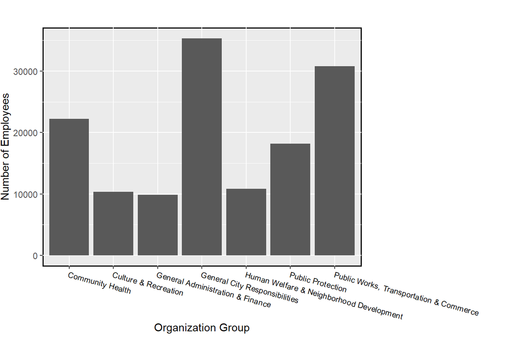

```r
Total_OEmployee_graph <- ggplot(Total_OEmployee, aes(x = `Organization Group`, y = `Number of Employees`)) + geom_col() + theme(axis.text.x = element_text(size=8, angle = 345, vjust = 1, hjust = 0, color = "black"), panel.background = element_rect(color = "black" , size = 1),  aspect.ratio = .75, plot.margin =  margin(t = 0, r = 2, b = 0, l = 0, unit = "in"))

Total_OEmployee_graph
```

The data set also shows the earnings of each of Employee from the years 2019 to 2013. This includes their Total Salaries, Total Compensations, and Total Benefits. The average Total Salary that all employees are paid is $50354 while the highest amount one is $393158. For Total Benefits, the average is $19738 and the max is $108384, while Total Compensation has the average of $70114 and the max of $501542. In the graph below, we can look at the average Total Salary each employee makes and observe that most city are making between $0 to $100,000 a year. *NOTE: We did not include submissions that have a negative Total Salary.

```r
Total_Salary_Ave <- Employee_Compensation%>%  group_by(`Employee Identifier`, `Job Code`) %>% filter(`Total Salary` >= 0 & !is.nan(`Total Salary`)) %>% summarise(`Salary Mean` = mean(`Total Salary`, na.rm=T))

Total_Salary_Ave
```

```
## # A tibble: 120,474 x 3
## # Groups:   Employee Identifier [102,652]
##    `Employee Identifier` `Job Code` `Salary Mean`
##                    <dbl> <chr>              <dbl>
##  1                     1 9163              79759.
##  2                     2 2586              49366
##  3                     2 9705              62569.
##  4                     3 H002              16188.
##  5                     4 2303              55549.
##  6                     5 9916               9663.
##  7                     6 2708              53005.
##  8                     7 9163              40332.
##  9                     8 7355              80377.
## 10                     9 3278               6774.
## # ... with 120,464 more rows
```

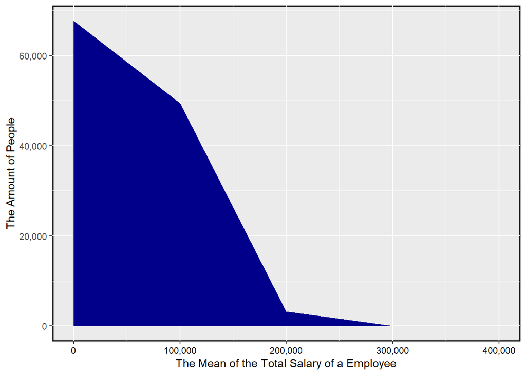

```r
Total_Salary_Ave_Graph <- ggplot(data = Total_Salary_Ave, aes(`Salary Mean`)) + geom_area(stat = "bin", binwidth = 100000, fill = "darkblue") +  scale_x_continuous(name = "The Mean of the Total Salary of a Employee", breaks= waiver(), labels = comma,limits = c(0,400000)) + scale_y_continuous(name="The Amount of People", breaks= waiver(), label = comma) + theme(axis.text.x = element_text(color = "black"), panel.background = element_rect(color = "black" , size = 1))

Total_Salary_Ave_Graph
```

### **Part 5: Research Questions**

Some research questions I hope to answer in the future: 1. What is the best San Francisco city job to work for? This questions sounds easy to answer but there are different factors of a job that comes in such as time and work one puts into it, as well as the level of difficulty and dangers of it.

2. What main factors of a job will make people want to work for the city of San Francisco and how could we promote these city jobs? What is difficult about answering this questions is that many different reasons why someone would work for the city, it may because they wanted desired to have a specific job, such as a police officer, or they wanted to stay in San Francisco to live and have a family.
3. How can the city gain more money to finance their jobs, what actions could they take to give workers more benfits? This may be a more political questions as the government would be making the final decesions.